# Homework 1 Question 1

Yuval Saraf

3/29/2020

#### Preparation

```r
nflSalaries = read.csv('NFL-salaries.csv');
nflSalaries$SalaryNum = as.numeric(stringr::str_remove(nflSalaries$Salary, '\\$'));
summary(nflSalaries);
```

```
##        Rk            Player              Pos                 Tm
##  Min.   :   1.0   Length:1914        Length:1914        Length:1914
##  1st Qu.: 209.5   Class :character   Class :character   Class :character
##  Median : 553.5   Mode  :character   Mode  :character   Mode  :character
##  Mean   : 571.4
##  3rd Qu.: 848.2
##  Max.   :1914.0
##  NA's   :1462
##     Salary            SalaryNum
##  Length:1914        Min.   :  378000
##  Class :character   1st Qu.:  570000
##  Mode  :character   Median :  777627
##                     Mean   : 1860770
##                     3rd Qu.: 1726191
##                     Max.   :27500000
##
```

1. Find the subset of players that earned at least $1,000,000. Assign those rows to the variable BigBucks.

   ```r
       minForBigBucks = 10^6;
       BigBucks = nflSalaries[nflSalaries$SalaryNum >= minForBigBucks, ];
       summary(BigBucks)
   ```

   ```
   ##        Rk           Player              Pos                 Tm
   ##  Min.   :  1.0   Length:739         Length:739         Length:739
   ##  1st Qu.:121.5   Class :character   Class :character   Class :character
   ##  Median :305.5   Mode  :character   Mode  :character   Mode  :character
   ##  Mean   :321.8
   ##  3rd Qu.:540.2
   ##  Max.   :669.0
   ##  NA's   :447
   ##     Salary            SalaryNum
   ##  Length:739         Min.   : 1000000
   ##  Class :character   1st Qu.: 1375836
   ##  Mode  :character   Median : 2025000
   ##                     Mean   : 3812937
   ##                     3rd Qu.: 5000000
   ##                     Max.   :27500000
   ##
   ```

   1. How many players are on this list?

      ```r
      nrow(BigBucks);
      ```

      ```
      ## [1] 739
      ```

   2. Draw a histogram of the salaries of the Players in the BigBucks category.
      - In order to improve the readability of the histogram, scale the data so that the salaries are in millions of dollars. For example, Cousins earned $27,500,000. You would depict this as 27.5.
      - Of course, you need to provide an appropriate label for the x-axis so that it is clear that this is $ 27.5M and not twenty-seven dollars and 50 cents
      - Set the number of bins in the histogram to 5 using the “breaks” parameter. (use ‘?hist’ for details)
      - Save the plot to a PDF
      - Open the PDF file to make sure that you succeeded.

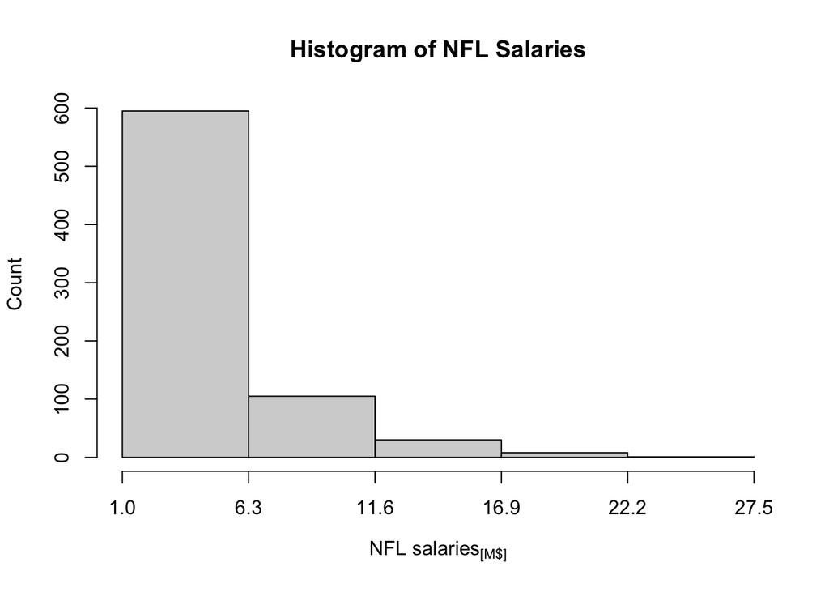

      ```r
      desiredBins = 5;
      nflSalariesInMillions = BigBucks$SalaryNum / 10^6;
      minSalaryInMillions = min(nflSalariesInMillions);
      maxSalaryInMillions = max(nflSalariesInMillions);

      xaxis = seq(from = minSalaryInMillions, to = maxSalaryInMillions, length.out = desiredBins + 1);

      drawHist <- function() {
          hist(
              nflSalariesInMillions,
              xaxt = 'n',
              main = 'Histogram of NFL Salaries',
              xlab = expression('NFL salaries'['[M$]']),
              ylab = 'Count',
              breaks = xaxis
          );
          axis(1, at = xaxis);
      }

      pdf('histogram-NFL-salaries.pdf');
      drawHist();
      suppressMessages <- dev.off();

      drawHist();
      ```

2. Analyze the entire dataset to find out how many players make the lowest salary. Start by finding the minimum salary and find those players that make that minimum salary.

   ```r
   minSalary = min(nflSalaries$SalaryNum);
   minBucks = nflSalaries[nflSalaries$SalaryNum == minSalary, ];
   nrow(minBucks);
   ```

   ```
   ## [1] 1
   ```

   ```r
   minBucks
   ```

   ```
   ##        Rk                   Player Pos  Tm  Salary SalaryNum
   ## 1914 1914 Tyrone Swoopes\\SwooTy00  TE SEA $378000    378000
   ```

3. How many players earn more than 10 million?

   ```r
   superBigBucks = nflSalaries[nflSalaries$SalaryNum >= 10 * 10^6, ];
   nrow(superBigBucks);
   ```

   ```
   ## [1] 61
   ```